# Assumptions in Causal Inference

Lucy D’Agostino McGowan

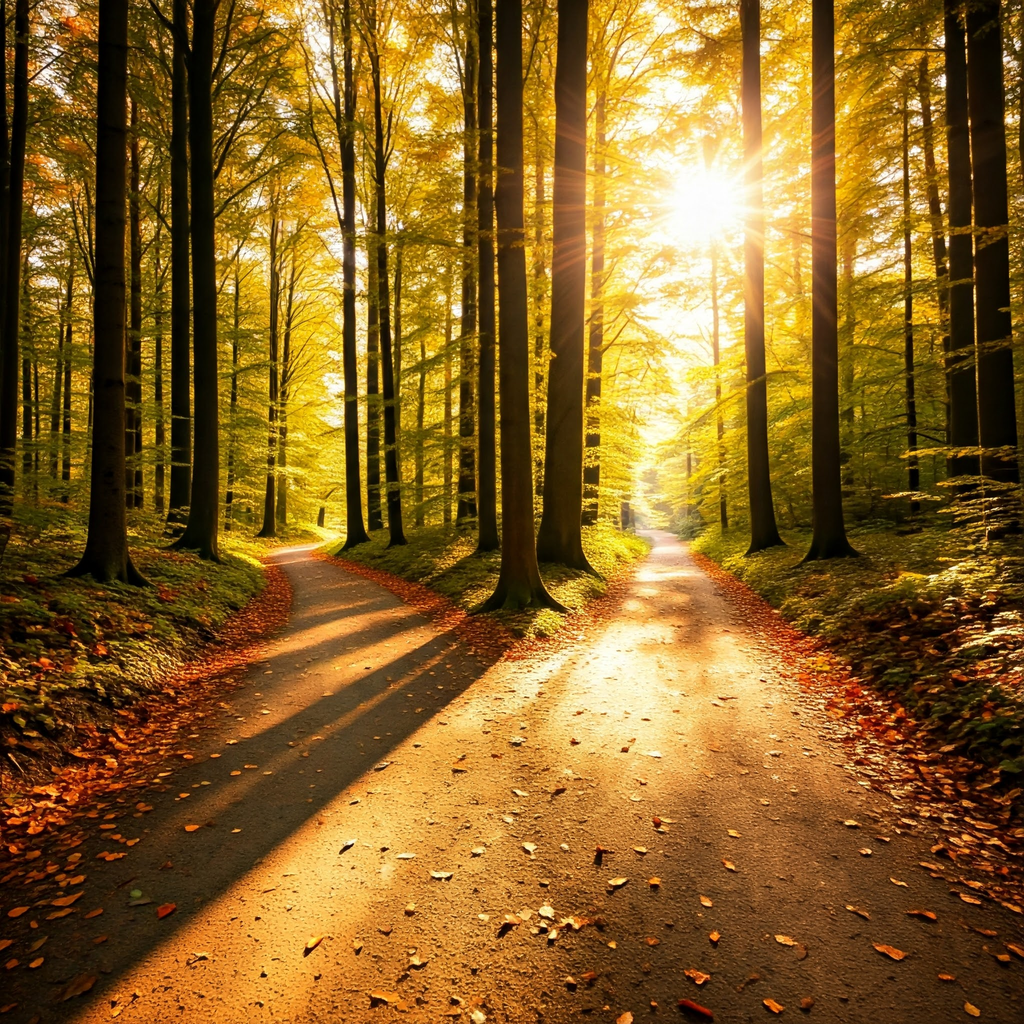

*Image generated with Gemini*

Two roads diverged in a yellow wood,  
And sorry I could not travel both  
And be one traveler, long I stood  
And looked down one as far as I could  
To where it bent in the undergrowth  
*— Robert Frost*

## Potential outcomes

- Prior to some “cause” occurring, the *potential outcomes* are all of the potential things that could occur depending on what you end up exposed to

## Potential outcomes

- Let’s assume an exposure has two levels:
  - $X=1$ if you are exposed
  - $X=0$ if you are not exposed

## Potential outcomes

- Under this simple scenario, there are two potential outcomes:
  - $Y(1)$ the potential outcome if you are exposed
  - $Y(0)$ the potential outcome if you are not exposed

## Potential outcomes

- Only *one* of these potential outcomes will actually be realized
- It is important to remember here that these exposures are defined at a particular instance in time, so *only one* can happen to any individual
- In the case of a binary exposure, this leaves one potential outcome as *observable* and one *missing*

## Potential outcomes

- Our causal effect of interest is often some difference in potential outcomes $Y(1) - Y(0)$, averaged over a particular population

## Counterfactuals

- Early causal inference methods were often framed as missing data problems
- We need to make certain assumptions about the *missing counterfactuals*, the value of the potential outcome corresponding to the exposure(s) that did not occur
- We *wish* we could observe the conterfactual outcome that would have occurred in an alternate universe

## Counterfactuals

- To do this, we attempt to control for all factors that are related to an exposure and outcome such that we can *construct* (or estimate) such a counterfactual outcome.

## Ice-T and Spike

### **Split Decision: Life Stories**

Award-winning actor, rapper, and producer Ice-T unveils a compelling memoir of his early life robbing jewelry stores until he found fame and fortune—while a handful of bad choices sent his former crime partner down an incredibly different path.

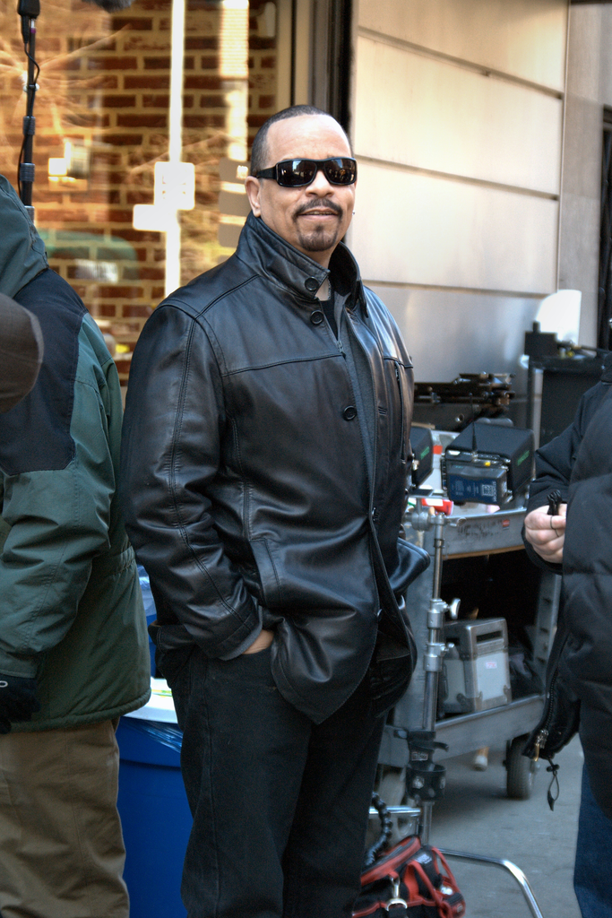

Vicky, CC BY 2.0 https://creativecommons.org/licenses/by/2.0, via Wikimedia Commons

## Ice-T and Spike

```
flowchart LR
A{Ice-T} --> |observed| B(Abandons criminal life)
A -.-> |missing counterfactual| C(Does one more heist)
C -.-> D[35 years in prison]
B --> E[Fame & Fortune]

classDef grey fill:#fff
class D,C grey
```

```
flowchart LR
A{Spike} -.-> |missing counterfactual| B(Abandons criminal life)
A --> |observed| C(Does one more heist)
C --> D[35 years in prison]
B -.-> E[Fame & Fortune]
classDef grey fill:#fff
class E,B grey
```

## Ice-T and Spike

- What would need to be true for us to draw a causal conclusion?
- Can we really conclude that Spike’s life would have turned out exactly like Ice-T’s if he had made the exact same choices as Ice-T?

## In practice

- We could conduct an experiment where we *randomize* many individuals to leave criminal life (or not) and see how this impacts their outcomes *on average*
- This randomized trial seems to present some ethical issues, perhaps we need to look to *observational* studies to help answer this question
- We must rely on statistical techniques to help construct these unobservable counterfactuals
1. **Consistency**
2. **Exchangeability**
3. **Positivity**

## Consistency

- We assume that the causal question you claim you are answering is consistent with the one you are *actually* answering with your analysis.
- Mathematically: $Y_{obs} = (X)Y(1) + (1-X)Y(0)$
- **Well defined exposure**
- **No interference**

## Well defined exposure

- We assume that for each value of the exposure, there is no difference between subjects in the delivery of that exposure
- Put another way, multiple versions of the treatment do not exist

## No interference

- We assume that the outcome (technically all *potential* outcomes, regardless of whether they are observed) for any subject does not depend on another subject’s exposure

## Exchangeability

- We assume that within levels of relevant variables (confounders), exposed and unexposed subjects have an equal likelihood of experiencing any outcome prior to exposure
- i.e. the exposed and unexposed subjects are exchangeable
- This assumption is sometimes referred to as **no unmeasured confounding**.

## Positivity

- We assume that within each level and combination of the study variables used to achieve exchangeability, there are exposed and unexposed subjects.
- Said differently, each individual has some chance of experiencing every available exposure level.
- Sometimes this is referred to as the **probabilistic** assumption.

# The Target Trial Framework

## Randomization

- **Purpose of Randomization**: Solves key issues in causal inference
  - Consistency
  - Positivity
  - Does not address interference

## Ideal vs Realizstic Randomized Trials

- **Ideal Randomized Trials**
  - Achieve exchangeability
- **Realistic Randomized Trials**
  - May violate exchangeability with non-adherence / dropout

| Assumption | Ideal Randomized Trial | Realistic Randomized Trial | Observational Study |
| --- | --- | --- | --- |
| Consistency (Well defined exposure) | 😄 | 😄 | 🤷 |
| Consistency (No interference) | 🤷 | 🤷 | 🤷 |
| Positivity | 😄 | 😄 | 🤷 |
| Exchangeability | 😄 | 🤷 | 🤷 |

# Study Protocol

1. Eligibility criteria
2. Exposure definition
3. Assignment procedures
4. Follow-up period
5. Outcome definition
6. Causal contrast of interest
7. Analysis plan

## Protcol elements mapped to assumptions

| Assumption | Eligibility Criteria | Exposure Definition | Assignment Procedures | Follow-up Period | Outcome Definition | Causal contrast | Analysis Plan |
| --- | --- | --- | --- | --- | --- | --- | --- |
| Consistency (Well-defined exposure) | ✔️ | ✔️ | ✔️ |  |  |  | ✔️ |
| Consistency (No interference) | ✔️ | ✔️ | ✔️ |  | ✔️ |  | ✔️ |
| Positivity | ✔️ | ✔️ | ✔️ |  |  | ✔️ | ✔️ |
| Exchangeability | ✔️ | ✔️ | ✔️ | ✔️ | ✔️ | ✔️ | ✔️ |

## Mapped to diagraming causal claims

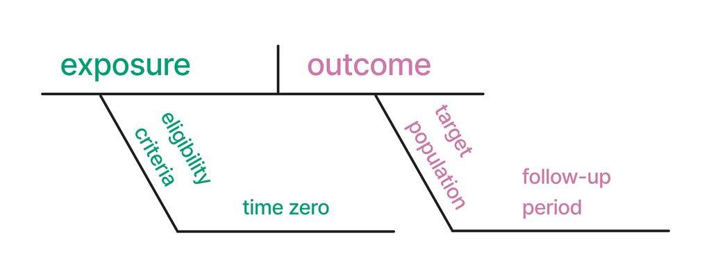

# Target Trials

## Target Trials

- There are many reasons why randomization may not be possible
  - it might not be ethical to randomly assign people to a particular exposure
  - there may not be funding available
  - there might not be enough time to conduct a full trial

## Target Trial

- In these situations, we rely on observational data to help us answer causal questions by implementing a *target trial*
- A *target trial* answers: What experiment would you design if you could?